# nanoSPLITS C10 Pooled Cell Experiment - R Markdown File (Figure 2 and associated supplementary figures)

James M. Fulcher

Last updated: 11/21/2023

# Introduction

This markdown file details the data structure and code used to generate figures for the nanoSPLITS manuscript. For this experiment, C10 mouse type II alveolar cells of different quantities (11 cells, n =6, 3 cells n= 6, and 1 cell n = 8) were split for parallel transcriptomics and proteomics. For transcriptomics, both raw counts and TPM normalized values were utilized. For proteomics, summarize protein intensities and riBAQ values were utilized.

# Proteomics

## Data Quality Control

For quality control of proteomics data, samples with less than 2,600 identified proteins were removed from downstream analysis (Supplementary Figure 3).

# Transcriptomics

## Data structure

We import “C10_pooledcells_Counts_subset.txt” and “C10_pooledcells_TPM_subset.txt” for raw counts and TPM normalized expression values of the transcriptomic data, respectively. Raw counts are only used for quality control, while all figures utilize TPM normalized values.

## Data Quality Control

For quality control of transcriptomics data, samples with less than 3,000 genes with at least 5 counts were excluded from downstream analysis.

# Relevant Code Chunks

## Data import

```r
path <- "./"
knitr::opts_chunk$set(echo = TRUE)
knitr::opts_knit$set(rootdir = path)
setwd(path)
library(tidyverse); library(proDA); library(knitr);
library(aLFQ); library(ggrepel); library(reshape2); library(vegan);
library(corrplot); library(org.Mm.eg.db); library(AnnotationDbi);
library(corrr); library(reshape2); library(mygene); library(lessR)

#library(extrafont)
#loadfonts(device = "win")

## Function used to convert class AsIs to list for figure 2d
unAsIs <- function(X) {
    if("AsIs" %in% class(X)) {
        class(X) <- class(X)[-match("AsIs", class(X))]
    }
    X
} ######### Credit https://stackoverflow.com/questions/12865218/getting-rid-of-asis-class-attribute




RNAx_TPM <- read.delim("C10_pooledcells_TPM_subset.txt")

RNAx_counts <- read.delim("C10_pooledcells_Counts_subset.txt")

Chip2cell <- read_tsv("C10_pooledcells_Protein_intensities.tsv", show_col_types = FALSE)

protlist <- read.csv("protlist.csv")


test <- read.csv("riBAQ.csv")

convert <- read_tsv("convert_uniprot.tsv")
```

## Normalization and Supplementary Figure X code (prenormalization figure)

```r
allcell <- Chip2cell %>%
  dplyr::select(starts_with("PROTID")| starts_with("Chip2")) %>%
  filter(!grepl("contam_sp", PROTID))
allcell_long <- allcell %>%
  pivot_longer(!PROTID, names_to = "SampleID", values_to = "Intensity") %>%
  filter(!grepl("_Ctrl_", SampleID)) %>%
  mutate(SampleID = gsub("_INT", "", SampleID)) %>%
  mutate(SampleID = gsub("Chip2_", "", SampleID)) %>%
  filter(Intensity > 0) %>%
    mutate(Cells = case_when(grepl("11cells", SampleID) ~ "11",
                           grepl("3cells", SampleID) ~ "3",
                           grepl("1cell", SampleID) ~ "1"))

Cell11 <- Chip2cell %>%
  dplyr::select(starts_with("PROTID")| starts_with("Chip2_11cells")) %>%
  filter(!grepl("contam_sp", PROTID))
Cell11 <- Cell11 %>% remove_rownames %>% column_to_rownames(var="PROTID")
Cell11[Cell11 == 0] <- NA
Cell11[,1:6] <- log2(Cell11[,1:6])
Cell11 <- as.data.frame(median_normalization(as.matrix(Cell11)))
Cell11_long <- Cell11 %>%
  rownames_to_column(., "PROTID") %>%
  pivot_longer(!PROTID, names_to = "SampleID", values_to = "Intensity")

Cell3 <- Chip2cell %>%
  dplyr::select(starts_with("PROTID")| starts_with("Chip2_3cells")) %>%
  filter(!grepl("contam_sp", PROTID))
Cell3 <- Cell3 %>% remove_rownames %>% column_to_rownames(var="PROTID")
Cell3[Cell3 == 0] <- NA
Cell3[,1:6] <- log2(Cell3[,1:6])
Cell3 <- as.data.frame(median_normalization(as.matrix(Cell3)))
Cell3_long <- Cell3 %>%
  rownames_to_column(., "PROTID") %>%
  pivot_longer(!PROTID, names_to = "SampleID", values_to = "Intensity")

Cell1 <- Chip2cell %>%
  dplyr::select(starts_with("PROTID")| starts_with("Chip2_1cell")) %>%
  filter(!grepl("contam_sp", PROTID))

Cell1 <- Cell1 %>% remove_rownames %>% column_to_rownames(var="PROTID")
Cell1[Cell1 == 0] <- NA
Cell1[,1:8] <- log2(Cell1[,1:8])
Cell1 <- as.data.frame(median_normalization(as.matrix(Cell1)))
Cell1_long <- Cell1 %>%
  rownames_to_column(., "PROTID") %>%
  pivot_longer(!PROTID, names_to = "SampleID", values_to = "Intensity")

x_long <- rbind(Cell11_long,Cell3_long,Cell1_long) %>%
  mutate(Cells = case_when(grepl("11cells", SampleID) ~ "11",
                           grepl("3cells", SampleID) ~ "3",
                           grepl("1cell", SampleID) ~ "1")) %>%
  mutate(Intensity = 2^Intensity) %>%
  filter(!is.na(Intensity)) %>%
  mutate(SampleID = gsub("_INT", "", SampleID)) %>%
  mutate(SampleID = gsub("Chip2_", "", SampleID)) %>%
  dplyr::select(PROTID, SampleID, Intensity, Cells)

supp1 <-allcell_long %>%
  filter(!is.na(Intensity)) %>%
  ggplot()+
  aes(x = fct_reorder(SampleID,-Intensity), y = log2(Intensity), fill = fct_relevel(Cells, "11", "3","1"))+
  geom_boxplot(alpha = 0.5, show.legend = FALSE, size = 1)+
  theme_bw(base_size = 14) +
  theme(panel.background = element_rect(fill= 'white'),
        axis.text.y=element_text(color = 'black', size = 14),
        axis.text.x=element_text(angle = 90, vjust = 0.5, hjust= 0.5, color='black',size = 14),
        panel.grid.minor = element_blank(),
        panel.grid.major = element_blank(),
        panel.border = element_blank(),
        text=element_text(family="Helvetica")) +
  ylab("log2(LFQ Intensity)") +
  xlab("Sample ID")+
  scale_x_discrete(labels=function(x){sub("\\s", "\n", x)})
```

## Supplementary Figure X code (post-normalization)

```r
supp2 <- x_long %>%
  filter(!is.na(Intensity)) %>%
  ggplot()+
  aes(x = fct_reorder(SampleID,-Intensity), y = log2(Intensity), fill = fct_relevel(Cells, "11", "3","1"))+
  geom_boxplot(alpha = 0.5, show.legend = FALSE, size = 1)+
  theme_bw(base_size = 14) +
  theme(panel.background = element_rect(fill= 'white'),
        axis.text.y=element_text(color = 'black', size = 14),
        axis.text.x=element_text(angle = 90, vjust = 0.5, hjust= 0.5, color='black',size = 14),
        panel.grid.minor = element_blank(),
        panel.grid.major = element_blank(),
        panel.border = element_blank(),
        text=element_text(family="Helvetica")) +
  ylab("log2(LFQ Intensity)") +
  xlab("Sample ID")+
  scale_x_discrete(labels=function(x){sub("\\s", "\n", x)})
```

## Supplementary Figure X code (Protein QC cutoff)

```r
  filterx <- unique(x_long$SampleID)

labels <- x_long %>%
  group_by(SampleID) %>%
  add_count(name = "n") %>%
  ungroup() %>%
  distinct(SampleID,Cells,n) %>%
  filter(n < 2600)

 supp3 <- x_long %>%
  group_by(SampleID) %>%
  add_count(name = "n") %>%
  ungroup() %>%
  distinct(SampleID,Cells,n) %>%
  ggplot()+
  aes(x = fct_relevel(Cells, "11", "3","1"), y = n, color = fct_relevel(Cells, "11", "3","1"))+
  geom_jitter(position = position_jitter(w = 0.1, h = 0), size = 3)+
    theme_bw(base_size = 14) +
  theme(legend.position = "none",
    panel.background = element_rect(fill= 'white'),
        axis.text.y=element_text(color = 'black', size = 14),
        axis.text.x=element_text(angle = 0, vjust = 0.5, hjust= 0.5, color='black',size = 14),
                panel.grid.minor = element_blank(),
        panel.grid.major = element_blank(),
        panel.border = element_blank(),
        axis.line = element_line(),
        text=element_text(family="Helvetica")) +
  ylab("Proteins Quantified (n)")+
    scale_color_manual(values = c("#88419d", "#8c96c6", "#b3cde3"))+
  xlab("Number of cells")+
  geom_hline(yintercept=2600, size = 1, linetype='dotted', col = 'red')+
  annotate("text", x = 2, y = 2600, label = "QC Cutoff", vjust = -0.5)+
  geom_label_repel(data=labels,
             aes(label = SampleID))

x_long <- x_long %>%
  group_by(SampleID) %>%
  add_count(name = "n") %>%
  filter(n >= 2600) %>%
  dplyr::select(-n)
```

## Figure 2a code (proteomics)

```r
main1 <- x_long %>%
  filter(!is.na(Intensity)) %>%
  distinct(SampleID,PROTID, Cells) %>%
  group_by(SampleID) %>%
  add_count(name = "n") %>%
  ungroup() %>%
  distinct(SampleID,Cells,n) %>%
  group_by(Cells) %>%
  summarise_at("n", funs(mean, sd)) %>%
  ggplot()+
  aes(x = fct_relevel(Cells, "11", "3","1"), y = mean, fill = fct_relevel(Cells, "11", "3","1"))+
  geom_bar(stat= "identity",show.legend = FALSE, alpha = 0.5, color = "black")+
  theme_bw(base_size = 28) +
  theme(panel.background = element_rect(fill= 'white'),
        axis.text.y=element_text(color = 'black', size = 28),
        axis.text.x=element_text(angle = 0, vjust = 0.5, hjust= 0.5, color='black',size = 28),
                panel.grid.minor = element_blank(),
        panel.grid.major = element_blank(),
        panel.border = element_blank(),
        axis.line = element_line(),
        text=element_text(family="Helvetica")) +
  ylab("Proteins Detected (n)")+
  scale_x_discrete(labels=function(x){sub("\\s", "\n", x)}) +
  scale_fill_manual(values = c("#88419d", "#8c96c6", "#b3cde3"))+
  geom_errorbar( aes(x=fct_relevel(Cells, "11", "3","1"),
                     ymin=mean-sd, ymax=mean+sd), width=0.4, colour="black", alpha=1, size=1.2) +
  xlab("Number of Cells")
```

## Figure 2b code (proteomics)

```r
xmed <- x_long %>%
  filter(!is.na(Intensity)) %>%
  group_by(Cells, PROTID) %>%
  add_count(name = "Obs") %>%
  filter(Obs >= 2) %>%
  mutate(CV = sd(Intensity)/mean(Intensity)) %>%
  distinct(Cells, PROTID,CV) %>%
  group_by(Cells) %>%
  mutate(med = median(CV)) %>%
  distinct(Cells, med) %>%
  ungroup()

main2 <- x_long %>%
  filter(!is.na(Intensity)) %>%
  group_by(Cells, PROTID) %>%
  add_count(name = "Obs") %>%
  filter(Obs >= 2) %>%
  mutate(CV = sd(Intensity)/mean(Intensity)) %>%
  distinct(Cells, PROTID,CV) %>%
  ggplot()+
   aes(x =fct_relevel(Cells, "11", "3","1"), y = CV, fill = fct_relevel(Cells, "11", "3","1"))+
  geom_violin(alpha = 0.5, show.legend = FALSE, size = 0)+
  scale_y_continuous(limits = c(0,1.6))+
  theme_bw(base_size = 28) +
  theme(legend.position = "none",
    panel.background = element_rect(fill= 'white'),
        axis.text.y=element_text(color = 'black', size = 28),
        axis.text.x=element_text(angle = 0, vjust = 0.5, hjust= 0.5, color='black',size = 28),
                panel.grid.minor = element_blank(),
        panel.grid.major = element_blank(),
        panel.border = element_blank(),
        axis.line = element_line(),
        text=element_text(family="Helvetica")) +
  ylab("Coefficent of Variation (CV)") +
  xlab("Number of Cells")+
  scale_x_discrete(labels=function(x){sub("\\s", "\n", x)}) +
  geom_text(data = xmed, aes(x = fct_relevel(Cells, "11", "3","1"), y = med, label = paste(round(med, digits = 2))),
            size = 9, vjust = -2.2,hjust = -0.25, show.legend = FALSE) +
  scale_fill_manual(values = c("#88419d", "#8c96c6", "#b3cde3"))

data_summary <- function(x) {
  m <- median(x)
  ymin <- m-sd(x)
  ymax <- m+sd(x)
  return(c(y=m,ymin=ymin,ymax=ymax))
}
 #plot +
#  stat_summary(fun.data=data_summary)
```

## Supplementary Figure X code (Protein intensity distributions)

```r
xmed <- x_long %>%
  filter(!is.na(Intensity)) %>%
  group_by(Cells) %>%
  summarize(med = round(median(log2(Intensity)), digits = 1))


supp4 <- x_long %>%
  ggplot()+
  aes(x = fct_relevel(Cells, "11", "3", "1"), y = log2(Intensity), fill = fct_relevel(Cells, "11", "3", "1"))+
  geom_boxplot(alpha = 0.5, show.legend = FALSE, size = 1)+
  #scale_y_continuous(limits = c(0,20))+
  theme_bw(base_size = 28) +
  theme(panel.background = element_rect(fill= 'white'),
        axis.text.y=element_text(color = 'black', size = 28),
        axis.text.x=element_text(angle = 0, vjust = 0.5, hjust= 0.5, color='black',size = 28),
        panel.grid.minor = element_blank(),
        panel.grid.major = element_blank(),
        panel.border = element_blank(),
        axis.line = element_line(),
        text=element_text(family="Helvetica")) +
  ylab("log2(Intensity)") +
  xlab("Number of Cells")+
  scale_x_discrete(labels=function(x){sub("\\s", "\n", x)}) +
  scale_fill_manual(values = c( "#88419d", "#8c96c6", "#b3cde3"))+
    geom_text(data = xmed, aes(x = fct_relevel(Cells, "11", "3","1"),
                  y = med,
                  label = med),
            size = 9, vjust = -2,hjust = -0.05, show.legend = FALSE)
```

## Figure 2c code

```r
comp <- x_long%>%
  filter(!is.na(Intensity)) %>%
  group_by(Cells, PROTID) %>%
  add_count(name = "Obs") %>%
  filter(Obs >= 2) %>%
  mutate(CV = sd(Intensity)/mean(Intensity)) %>%
  filter(CV <= 0.3) %>%
  dplyr::select(-Obs,-CV) %>%
  ungroup() %>%
  inner_join(x_long,by = c("PROTID"="PROTID")) %>%
 filter(SampleID.x >= SampleID.y) %>%  ### removes duplicate comparisons
  mutate(div = ifelse(grepl("3cells", SampleID.x) & grepl("1cell_",SampleID.y), Intensity.x/Intensity.y,
                      Intensity.y/Intensity.x)) %>%
  filter(div != 1)

main3 <- comp %>%
  mutate(CompVar = paste(Cells.x, Cells.y, sep = " vs ")) %>%
  group_by(CompVar) %>%
  filter(CompVar == "1 vs 11" | CompVar == "3 vs 11" | CompVar == "3 vs 1") %>%
  mutate(CompVar = case_when(CompVar == "1 vs 11" ~ "11 vs 1",
                             TRUE ~ CompVar)) %>%
  ggplot()+
  aes(x = fct_reorder(CompVar, div), y = div, fill = fct_reorder(CompVar, div))+
  geom_boxplot(alpha = 0.5, show.legend = FALSE,
               outlier.shape = NA, coef = 0.75 )+
  coord_flip()+
  theme_bw(base_size = 28) +
  theme(panel.background = element_rect(fill= 'white'),
        axis.text.y=element_text(vjust = 0.5, color = 'black', size = 28),
        axis.ticks.y = element_blank(),
        axis.text.x=element_text(color='black',size = 28),
        panel.grid.minor = element_blank(),
        panel.grid.major = element_blank(),
        panel.border = element_blank(),
        axis.line = element_line(),
        text=element_text(family="Helvetica")) +
  ylab("Protein Intensity Ratio") +
  xlab("")+
  scale_y_continuous(limits = c(0,20), expand = c(0,0))+
  scale_x_discrete(expand = c(0,0.5))
```

## RNAseq data wrangling and Supplementary Figure X code

```r
rm(allcell, allcell_long, Cell1, Cell1_long, Cell11, Cell11_long,
   Cell3, Cell3_long, Chip2cell, corx, corx2, med, corTest, plot,
   xmed)

RNAx2 <- RNAx_TPM %>%
  pivot_longer(!Gene, names_to = "SampleID", values_to = "TPM") %>%
  mutate(SampleID = gsub("Chip2_", "", SampleID)) %>%
  mutate(Cells = case_when(grepl("11cells", SampleID) ~ "11",
                           grepl("3cells", SampleID) ~ "3",
                           grepl("1cell", SampleID) ~ "1")) %>%
  filter(SampleID %in% filterx)

RNAx3 <- RNAx_counts %>%
  pivot_longer(!Gene, names_to = "SampleID", values_to = "Counts") %>%
  mutate(SampleID = gsub("Chip2_", "", SampleID)) %>%
  mutate(Cells = case_when(grepl("11cells", SampleID) ~ "11",
                           grepl("3cells", SampleID) ~ "3",
                           grepl("1cell", SampleID) ~ "1")) %>%
  filter(SampleID %in% filterx)

RNAx4 <- inner_join(RNAx2, RNAx3)



labels2 <- RNAx4 %>%
    filter(Counts > 4) %>%
  group_by(SampleID) %>%
  add_count(name = "n") %>%
  ungroup() %>%
  distinct(SampleID,Cells,n) %>%
  filter(n <= 3000)

RNAx5 <- RNAx4 %>%
  filter(Counts > 4) %>%
  group_by(SampleID) %>%
  add_count(name = "n") %>%
  filter(n >= 3000) %>%
  ungroup() %>%
  dplyr::select(-Counts, -n)

filterx2 <- RNAx5 %>%
  distinct(SampleID)



supp5  <- RNAx4 %>%
    filter(Counts > 4) %>%
  group_by(SampleID) %>%
  add_count(name = "n") %>%
  ungroup() %>%
  distinct(SampleID,Cells,n) %>%
  ggplot()+
  aes(x = fct_relevel(Cells, "11", "3","1"), y = n, color = fct_relevel(Cells, "11", "3","1"))+
  geom_jitter(position = position_jitter(w = 0.1, h = 0), size = 3)+
    theme_bw(base_size = 14) +
  theme(legend.position = "none",
    panel.background = element_rect(fill= 'white'),
        axis.text.y=element_text(color = 'black', size = 14),
        axis.text.x=element_text(angle = 0, vjust = 0.5, hjust= 0.5, color='black',size = 14),
                panel.grid.minor = element_blank(),
        panel.grid.major = element_blank(),
        panel.border = element_blank(),
        axis.line = element_line(),
        text=element_text(family="Helvetica")) +
  ylab("Genes Detected (n)")+
    scale_color_manual(values = c("#88419d", "#8c96c6", "#b3cde3"))+
  xlab("Number of cells")+
    geom_hline(yintercept=3000, size = 1, linetype='dotted', col = 'red')+
  annotate("text", x = 2, y = 3000, label = "QC Cutoff", vjust = -0.5)+
    geom_label_repel(data=labels2,
             aes(label = SampleID))
```

## Figure 2a code (transcriptomics)

```r
main5 <- RNAx5 %>%
  distinct(SampleID,Gene, Cells) %>%
  group_by(SampleID) %>%
  add_count(name = "n") %>%
  ungroup() %>%
  distinct(SampleID,Cells,n) %>%
  group_by(Cells) %>%
  summarise_at("n", funs(mean, sd)) %>%
  ggplot()+
  aes(x = fct_relevel(Cells, "11", "3","1"), y = mean, fill = fct_relevel(Cells, "11", "3","1"))+
  geom_bar(stat= "identity",show.legend = FALSE, alpha = 0.5, color = "black")+
  theme_bw(base_size = 28) +
  theme(panel.background = element_rect(fill= 'white'),
        axis.text.y=element_text(color = 'black', size = 28),
        axis.text.x=element_text(angle = 0, vjust = 0.5, hjust= 0.5, color='black',size = 28),
                panel.grid.minor = element_blank(),
        panel.grid.major = element_blank(),
        panel.border = element_blank(),
        axis.line = element_line(),
        text=element_text(family="Helvetica")) +
  ylab("Genes Detected (n)")+
  scale_x_discrete(labels=function(x){sub("\\s", "\n", x)}) +
  scale_fill_manual(values = c("#88419d", "#8c96c6", "#b3cde3"))+
  geom_errorbar( aes(x=fct_relevel(Cells, "11", "3","1"),
                     ymin=mean-sd, ymax=mean+sd), width=0.4, colour="black", alpha=1, size=1.2) +
  xlab("Number of Cells")
```

## Figure 2b code (transcriptomics)

```r
xmed <- RNAx5 %>%
  filter(!is.na(TPM)) %>%
  filter(TPM >= 1) %>%
  group_by(Cells, Gene) %>%
  add_count(name = "Obs") %>%
  filter(Obs >= 2) %>%
  mutate(CV = sd(TPM)/mean(TPM)) %>%
  distinct(Cells, Gene,CV) %>%
  group_by(Cells) %>%
  mutate(med = median(CV)) %>%
  distinct(Cells, med) %>%
  ungroup()



main6 <- RNAx5 %>%
   filter(!is.na(TPM)) %>%
    filter(TPM >= 1) %>%
  group_by(Cells, Gene) %>%
  add_count(name = "Obs") %>%
  filter(Obs >= 2) %>%
  mutate(CV = sd(TPM)/mean(TPM)) %>%
  distinct(Cells, Gene,CV) %>%
  ggplot()+
   aes(x =fct_relevel(Cells, "11", "3","1"), y = CV, fill = fct_relevel(Cells, "11", "3","1"))+
  geom_violin(alpha = 0.5, show.legend = FALSE, size = 0,
              scale = "count")+
  scale_y_continuous(limits = c(0,1.6))+
  theme_bw(base_size = 28) +
  theme(legend.position = "none",
    panel.background = element_rect(fill= 'white'),
        axis.text.y=element_text(color = 'black', size = 28),
        axis.text.x=element_text(angle = 0, vjust = 0.5, hjust= 0.5, color='black',size = 28),
                        panel.grid.minor = element_blank(),
        panel.grid.major = element_blank(),
        panel.border = element_blank(),
        axis.line = element_line(),
        text=element_text(family="Helvetica")) +
  #xlab("Condition")+
  ylab("Coefficent of Variation (CV)") +
  xlab("Number of Cells")+
  scale_x_discrete(labels=function(x){sub("\\s", "\n", x)}) +
  geom_text(data = xmed, aes(x = fct_relevel(Cells, "11", "3","1"), y = med, label = paste(round(med, digits = 2))),
            size = 9, vjust = 0.4,hjust = -0.1, show.legend = FALSE) +
  scale_fill_manual(values = c("#88419d", "#8c96c6", "#b3cde3"))

data_summary2 <- function(x) {
  m <- median(x)
  ymin <- m-sd(x)
  ymax <- m+sd(x)
  return(c(y=m,ymin=ymin,ymax=ymax))
}
#plot +
 # stat_summary(fun.data=data_summary)
```

## Supplementary Figure X code (riBAQ ranking)

```r
 test2 <- test %>%
  group_by(run_id) %>%
  mutate(Total = sum(response)) %>%
   ungroup() %>%
  mutate(riBAQ = response/Total) %>%
   group_by(protein_id) %>%
   summarize(median = median(riBAQ))

 test2$Rank <- rank(-test2$median)



  test3 <- test %>%
  group_by(run_id) %>%
  mutate(Total = sum(response)) %>%
  ungroup() %>%
  mutate(riBAQ = response/Total) %>%
    mutate(SampleID = run_id) %>%
  inner_join(., protlist) %>%
    dplyr::select(SampleID, PROTID, riBAQ)



test3 <- test3 %>%
  group_by(SampleID) %>%
  add_count(name = "n") %>%
  filter(n >= 2600) %>%
  dplyr::select(-n)


 supp6 <- test2 %>%
   ggplot()+
   aes(x = Rank, y = log2(median))+
   geom_point()+
   ylab("log2(rIBAQ)")+
   #scale_y_continuous(limits = c(0, -25))+
   geom_label_repel(data=test2 %>% filter(Rank <= 5),
              aes(label = protein_id), size = 4)+
   theme_minimal(base_size = 20)+
   theme(panel.grid.minor = element_blank(),
        panel.grid.major = element_blank(),
        panel.border = element_blank(),
        axis.line = element_line(),
        text=element_text(family="Helvetica"))
```

## Convert UNIPROT accessions to gene symbols, and perform inference

```r
columns(org.Mm.eg.db)

UniAc <- unique(test3$PROTID)

geneSymbols <- select(org.Mm.eg.db, keys=UniAc, columns= c("SYMBOL","UNIPROT"),
                      keytype="UNIPROT", multiVals="first")


geneSymbols <- geneSymbols %>%
  mutate(Gene = SYMBOL) %>%
  dplyr::select(Gene,UNIPROT)


geneSymbols <- full_join(geneSymbols, convert, by = c("Gene","UNIPROT")) %>%
  filter(!is.na(Gene))

test4 <- test3 %>%
  mutate(UNIPROT = PROTID) %>%
    mutate(Cells = case_when(grepl("11cells", SampleID) ~ "11",
                           grepl("3cells", SampleID) ~ "3",
                           grepl("1cell", SampleID) ~ "1"))

x_long2 <- full_join(test4,geneSymbols, by = "UNIPROT") %>%
  mutate(Gene = case_when(is.na(Gene) ~ UNIPROT,
                          TRUE ~ Gene)) %>%
  group_by(SampleID, Gene) %>%
  mutate(log2riBAQ = log2(riBAQ)) %>%
  slice_max(order_by = log2riBAQ, n = 1 , with_ties = FALSE)  %>%
  ungroup() %>%
  filter(SampleID %in% filterx2$SampleID)


###### Inference

combined3 <- full_join(x_long2, RNAx5, by = c("SampleID", "Gene", "Cells"))

inference1 <- combined3 %>%
  filter(!is.na(riBAQ) & !is.na(TPM)) %>%
  group_by(SampleID, riBAQ) %>%
  add_count(name = "n") %>%
  filter(n > 1) %>%
  ungroup() %>%
  distinct(Gene,UNIPROT)



inference2 <- combined3 %>%
  filter(!is.na(riBAQ) & !is.na(TPM)) %>%
  group_by(SampleID, riBAQ) %>%
  add_count(name = "n") %>%
  filter(n > 1) %>%
  distinct(n, Gene, TPM, UNIPROT) %>%
  group_by(Gene) %>%
  add_count(name  = "n2") %>%
  group_by(Gene) %>%
  slice_max(order_by = n2, n = 1) %>%
  mutate(med = median(TPM)) %>%
  group_by(UNIPROT) %>%
  slice_max(order_by = med, n = 1, with_ties = FALSE) %>%
  ungroup() %>%
  distinct(UNIPROT, Gene)

inference3 <- inference1 %>%
  filter(!Gene %in% inference2$Gene)

x_long3 <- x_long2 %>%
  filter(!Gene %in% inference3$Gene)



RNAx6 <- RNAx5 %>%
  mutate(SampleID = paste0(SampleID, "_RNA")) %>%
  filter(TPM >= 1) %>%
  mutate(log2riBAQ= log2(TPM))


combined4 <- full_join(x_long3, RNAx6)




combined5 <- combined4 %>%
  filter(!is.na(log2riBAQ)) %>%
  filter(!is.na(SampleID)) %>%
  dplyr::select(Gene, SampleID, log2riBAQ, Cells)
```

## Code for determining Pearson correlation distributions

```r
corx <- combined5%>%
  dplyr::select(-Cells) %>%
  arrange(SampleID) %>%
  spread(SampleID, log2riBAQ) %>%
  ungroup()

corx2 <- corx %>% remove_rownames %>% column_to_rownames(var="Gene")

corTest <- cor(corx2,method = "pearson", use = "pairwise.complete.obs")

corTest[lower.tri(corTest)] <- NA

corTest2 <- corTest %>%
  melt()

main8 <- corTest2 %>%
  filter(value != 1) %>%
  filter(!is.na(value)) %>%
  mutate(Cells1 = case_when(grepl("11cells", Var1) ~ "11",
                           grepl("3cells", Var1) ~ "3",
                           grepl("1cell", Var1) ~ "1")) %>%
  mutate(Cells2 = case_when(grepl("11cells", Var2) ~ "11",
                           grepl("3cells", Var2) ~ "3",
                           grepl("1cell", Var2) ~ "1")) %>%
  mutate(Comparison = case_when(grepl("_RNA", Var1) & grepl("_RNA", Var2) ~ "RNAseq (TPM)",
                                !grepl("_RNA", Var1) & !grepl("_RNA", Var2)~ "Proteomics (riBAQ)",
                                !grepl("_RNA", Var1) & grepl("_RNA", Var2) ~ "Proteomics vs RNAseq",
                                grepl("_RNA", Var1) & !grepl("_RNA", Var2) ~ "Proteomics vs RNAseq")) %>%
  ggplot()+
  aes(x = fct_relevel(Comparison, "Proteomics (riBAQ)",
                      "RNAseq (TPM)",
                      "Proteomics vs RNAseq"),
      y = value, fill = fct_relevel(Comparison, "Proteomics (riBAQ)",
                      "RNAseq (TPM)",
                      "Proteomics vs RNAseq"))+
  geom_boxplot(alpha = 0.5, show.legend = FALSE, size = 1)+
  theme_bw(base_size = 28) +
  theme(panel.background = element_rect(fill= 'white'),
        axis.text.y=element_text(color = 'black', size = 28),
        axis.text.x=element_text(angle = 0, vjust = 0.5, hjust= 0.5, color='black',size = 28),
        panel.grid.minor = element_blank(),
        panel.grid.major = element_blank(),
        panel.border = element_blank(),
        axis.line = element_line(),
        text=element_text(family="Helvetica")) +
  ylab("Pearson \n Correlation") +
  xlab("")+
  scale_x_discrete(labels=function(x){sub("\\s", "\n", x)})+
  scale_fill_manual(values = c("#073568", "#266daf",
  "#5ba2cb", "#77b4d4", "#92c5de"
))
```

## Code for determining gene/protein overlap across samples

```r
combined6 <- combined5 %>%
  filter(!is.na(log2riBAQ)) %>%
  dplyr::select(Gene, SampleID, log2riBAQ)


corx_test <- combined6%>%
  arrange(SampleID) %>%
  spread(Gene, log2riBAQ, fill = 0) %>%
  ungroup() %>%
  remove_rownames() %>%
  column_to_rownames("SampleID") %>%
  data.frame()

corx_test <- as.matrix(((corx_test>0 | corx_test < 0)+0))


check <- designdist(corx_test, "J/pmin(A,B)") %>%
  as.matrix()
check[check == 0] <- 1


corx <- combined6%>%
  arrange(SampleID) %>%
  spread(SampleID, log2riBAQ) %>%
  ungroup()

corx <- corx %>%
  remove_rownames() %>%
  column_to_rownames("Gene")

combined_cor <- Hmisc::rcorr(as.matrix(corx))

ncor <- as.matrix(combined_cor$n)


ncor[lower.tri(ncor)] <- NA

ncor2 <- ncor %>%
  melt()

main9 <- ncor2 %>%
  filter(Var1 != Var2) %>%
  filter(!is.na(value)) %>%
  mutate(Cells1 = case_when(grepl("11cells", Var1) ~ "11",
                           grepl("3cells", Var1) ~ "3",
                           grepl("1cell", Var1) ~ "1")) %>%
  mutate(Cells2 = case_when(grepl("11cells", Var2) ~ "11",
                           grepl("3cells", Var2) ~ "3",
                           grepl("1cell", Var2) ~ "1")) %>%
  mutate(Comparison = case_when(grepl("_RNA", Var1) & grepl("_RNA", Var2) ~ "RNAseq (TPM)",
                                !grepl("_RNA", Var1) & !grepl("_RNA", Var2)~ "Proteomics (riBAQ)",
                                !grepl("_RNA", Var1) & grepl("_RNA", Var2) ~ "Proteomics vs RNAseq",
                                grepl("_RNA", Var1) & !grepl("_RNA", Var2) ~ "Proteomics vs RNAseq")) %>%
  ggplot()+
  aes(x = fct_relevel(Comparison,"RNAseq (TPM)", "Proteomics (riBAQ)",
                      "Proteomics vs RNAseq"),
      y = value, fill = fct_relevel(Comparison,"RNAseq (TPM)",
                      "Proteomics (riBAQ)",
                      "Proteomics vs RNAseq"))+
  geom_boxplot(alpha = 0.5, show.legend = FALSE, size = 1)+
  theme_bw(base_size = 26) +
  theme(panel.background = element_rect(fill= 'white'),
        axis.text.y=element_text(color = 'black', size = 26),
        axis.text.x=element_text(angle = 0, vjust = 0.5, hjust= 0.5, color='black',size = 26),
        panel.grid.minor = element_blank(),
        panel.grid.major = element_blank(),
        panel.border = element_blank(),
        axis.line = element_line(),
        text=element_text(family="Helvetica")) +
  ylab("Gene/Protein \n Overlap(n)") +
  xlab("")+
  scale_x_discrete(labels=function(x){sub("\\s", "\n", x)})+
  scale_fill_brewer(palette = "Greens", direction = -1)
```

# Main Figures

## Figure 2a

**Figure 2a. Total genes detected in 11, 3, and 1 C10 cell after nanoSPLITS (transcriptomics)**

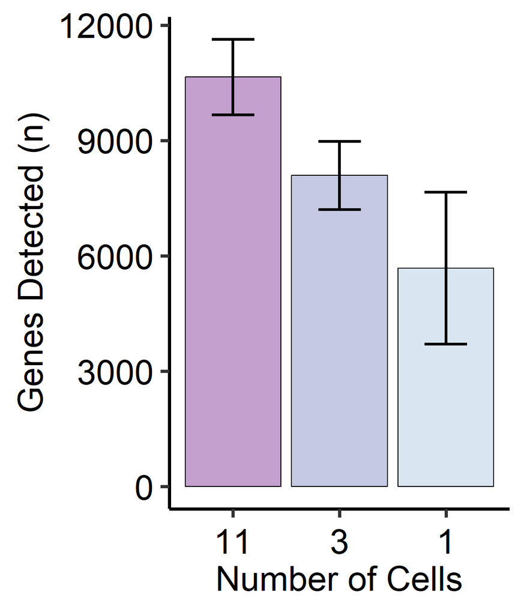

## Figure 2a

**Figure 2a. Total proteins quantified in 11, 3, and 1 C10 cell after nanoSPLITS**

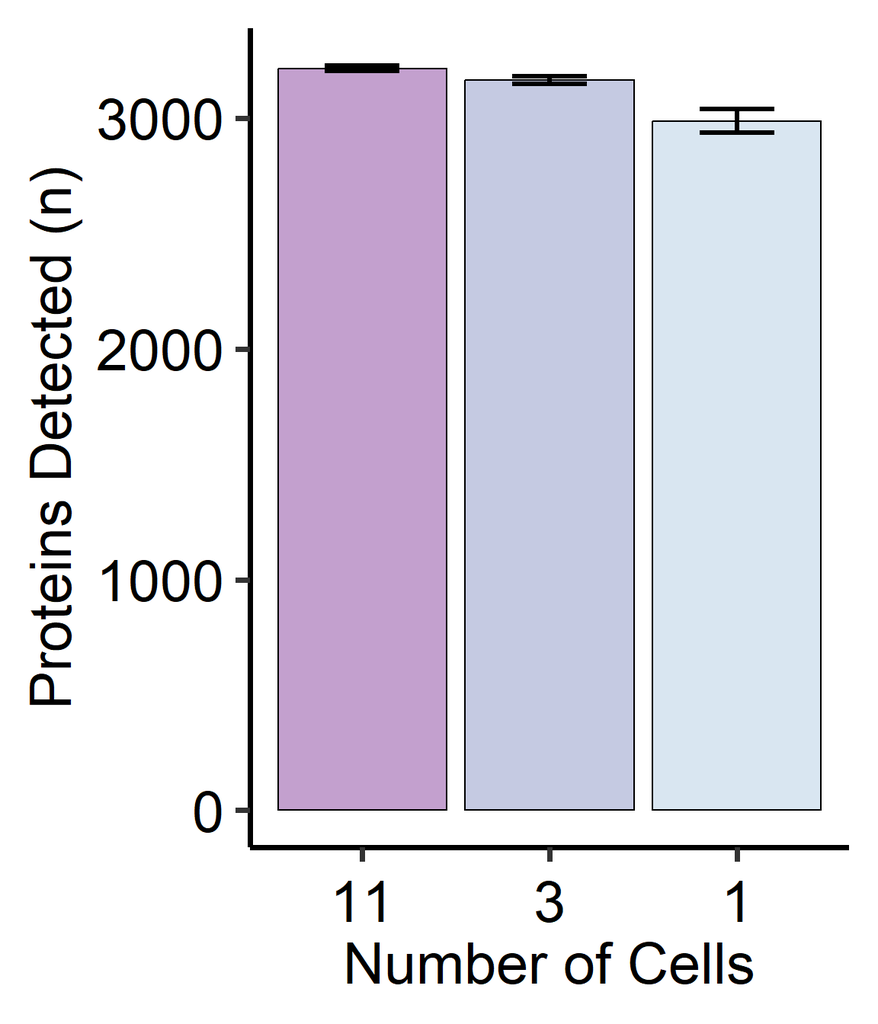

## Figure 2c

**Figure 2c. Coefficients of variation from RNAseq results**

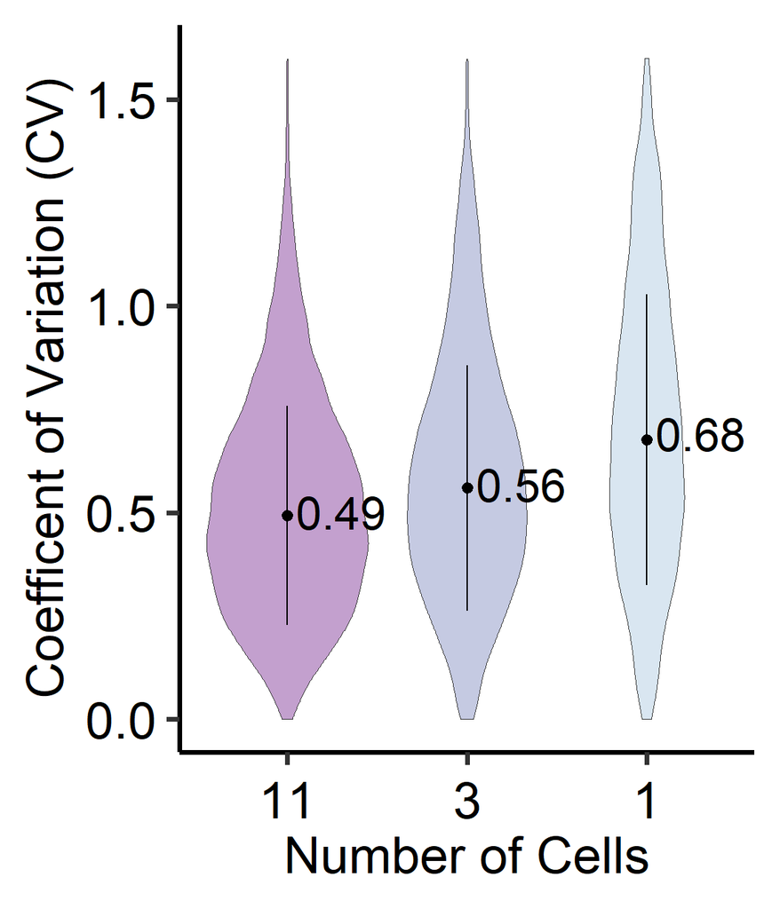

## Figure 2c

**Figure 2c. Coefficients of variation for LFQ proteomics of 11, 3, and 1 C10 cells**

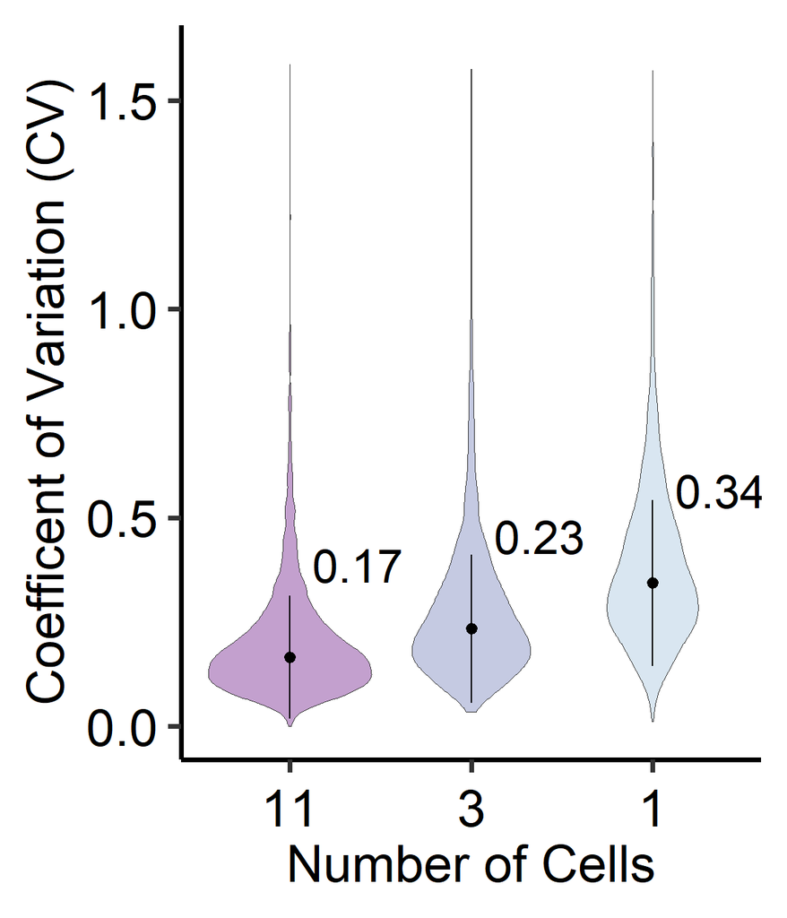

## Figure 2d

**Figure 2d. Distributions of the ratios of protein intensities between 11, 3, and 1 C10 cell**

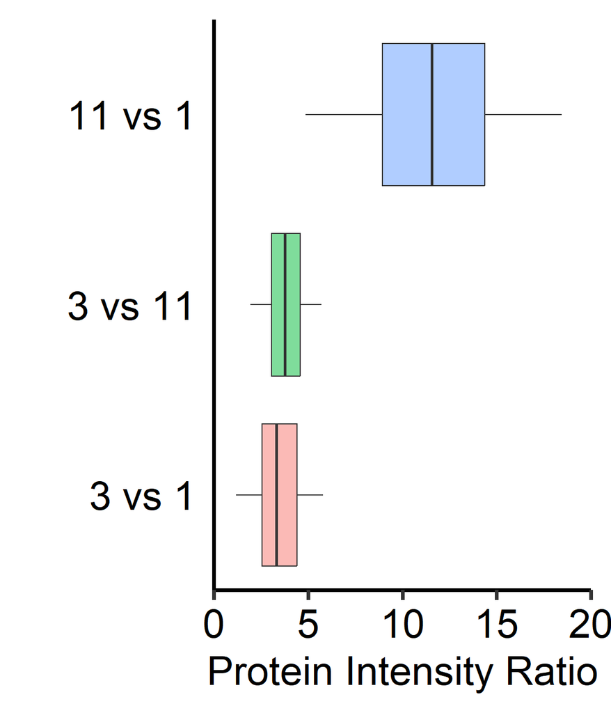

## Figure 2e (and associated code)

**Figure 2e: Pearson Correlation heatmap of RNAseq (TPM) and proteomics (riBAQ) data**

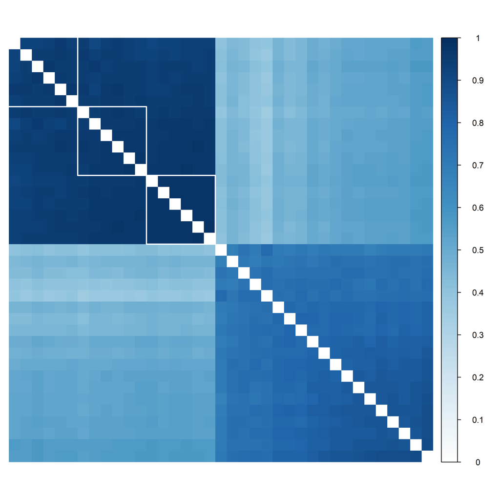

```r
corx <- combined5%>%
  dplyr::select(-Cells) %>%
  arrange(SampleID) %>%
  spread(SampleID, log2riBAQ) %>%
  ungroup()

corx2 <- corx %>% remove_rownames %>% column_to_rownames(var="Gene")

corTest <- cor(corx2,method = "pearson", use = "pairwise.complete.obs")

corrplot(corTest, method = 'shade', order = 'hclust',
         hclust.method = 'centroid',
         col.lim = c(0, 1),
         tl.pos = "n",
         cel.cex = 3,
         is.corr = TRUE, tl.srt = 45,
         diag = FALSE, tl.col = "black") %>%
  corrRect(c(0, 7, 13, 18), col = 'white')+
  theme(text=element_text(family="Helvetica"))
```

## Figure 2b (and associated code)

**Figure 2b. Pie chart of the localization of all genes/proteins found in the scRNAseq and scProteomic data**

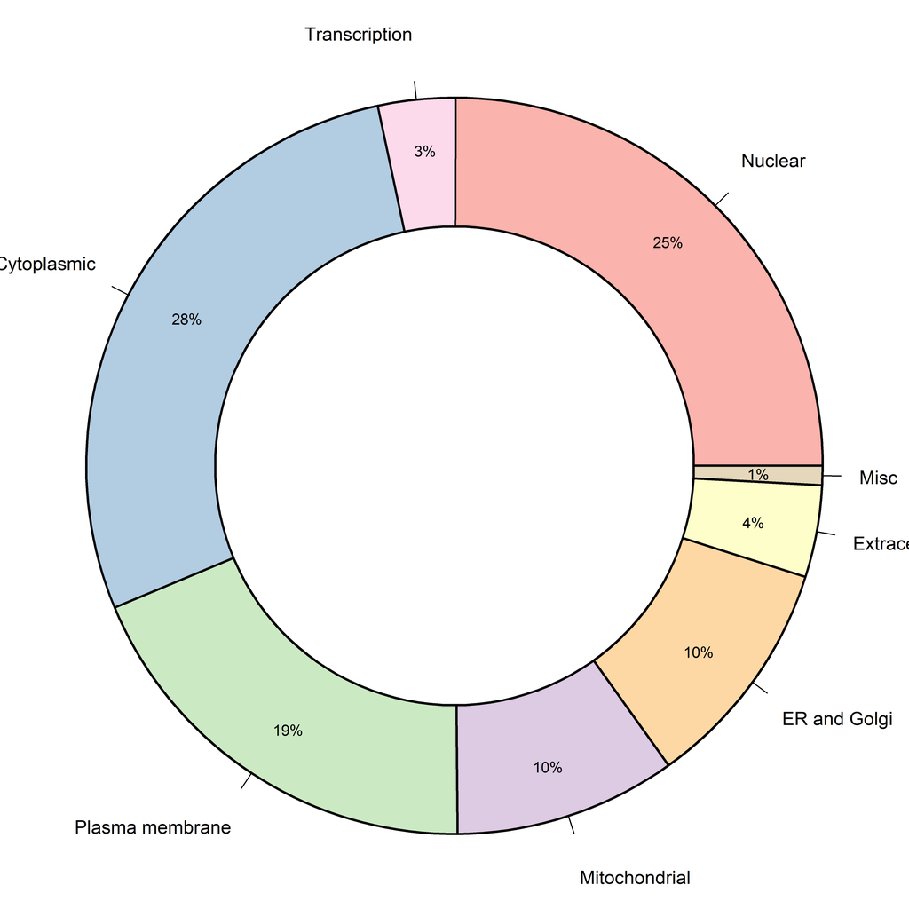

```r
gene_check <- x_long3 %>%
  filter(Cells  == "1") %>%
  distinct(Gene)

gene_query <-queryMany(gene_check$Gene, scopes='symbol',
                       fields=c('go'), species='mouse',
                       returnall = FALSE )
gq2 <- gene_query %>%
  as.data.frame() %>%
  mutate(go.CC = unAsIs(go.CC)) %>%
  mutate(go.MF = unAsIs(go.MF))

gq3 <- gq2 %>%
  dplyr::select(-go.BP, -go.MF) %>%
  hoist(go.CC,
        term =  "term",
        evidence = "evidence",
        qualifier = "qualifier",
        id = "id") %>%
  unnest(term, evidence, qualifier, id) %>%
  dplyr::select(-go.CC)

gq4 <- gq2 %>%
  dplyr::select(-go.BP, -go.CC) %>%
  hoist(go.MF,
        term =  "term",
        evidence = "evidence",
        qualifier = "qualifier",
        id = "id") %>%
  unnest(term, evidence, qualifier, id) %>%
  dplyr::select(-go.MF)

 transcriptf <- gq4 %>%
  filter(grepl("transcription", term)) %>%
  distinct(query) %>%
  mutate(Component = "Transcription")


nuclearp <- gq3 %>%
  filter(term == "nucleus" | term == "nucleoplasm" | term == "nucleolus"| grepl("nuclear", term)) %>%
  filter(qualifier == "located_in") %>%
  distinct(query)%>%
  mutate(Component = "Nuclear")




cytoplasmic <- gq3 %>%
  filter(qualifier == "located_in") %>%
  filter(term == "cytoplasm" | term == "cytosol") %>%
  distinct(query) %>%
  mutate(Component = "Cytoplasmic")

mitochondrial <- gq3 %>%
  filter(qualifier == "located_in") %>%
  filter(term == "mitochondrion" | grepl("mitochondria", term)) %>%
  distinct(query) %>%
  mutate(Component = "Mitochondrial")

plasmamembrane <- gq3 %>%
  filter(qualifier == "located_in") %>%
  filter(term == "plasma membrane" | term == "membrane") %>%
  distinct(query) %>%
  mutate(Component = "Plasma membrane")


ER_golgi <- gq3 %>%
  filter(qualifier == "located_in") %>%
  filter(grepl("Golgi", term) | grepl("endoplasmic reticulum", term)) %>%
  distinct(query) %>%
  mutate(Component = "ER and Golgi")

extraCel <- gq3 %>%
  filter(qualifier == "located_in") %>%
  filter(grepl("extracellular", term)) %>%
  distinct(query) %>%
  mutate(Component = "Extracellular")

misc <- gq3 %>%
 filter(!query %in% transcriptf$query) %>%
  filter(!query %in% nuclearp$query) %>%
  filter(!query %in% cytoplasmic$query) %>%
  filter(!query %in% mitochondrial$query) %>%
  filter(!query %in% plasmamembrane$query) %>%
  filter(!query %in% ER_golgi$query) %>%
  filter(!query %in% extraCel$query) %>%
  filter(qualifier == "located_in") %>%
  distinct(query) %>%
  mutate(Component = "Misc")

protein_component <- do.call("rbind",list(transcriptf, nuclearp,
                                          cytoplasmic, mitochondrial,
                                          plasmamembrane, ER_golgi,
                                          extraCel, misc)) %>%
  mutate(Component = as.factor(Component)) %>%
  mutate(Component = fct_relevel(Component, "Nuclear",
                                  "Transcription",
                                  "Cytoplasmic",
                                  "Plasma membrane",
                                  "Mitochondrial",
                                  ))


cols <- c("#fbb4ae", "#fddaec", "#b3cde3", "#ccebc5",
          "#decbe4", "#fed9a6", "#ffffcc", "#e5d8bd")



PieChart(Component, data = protein_component,
         values = "%",
         fill = cols,
         lwd = 2,
         lty = 1,
         values_size = 0.8,
         values_color = "black",
         color = "black",
         main = NULL,
         width = 10,
         heigth = 10)+
  theme(text=element_text(family="Helvetica"))
```

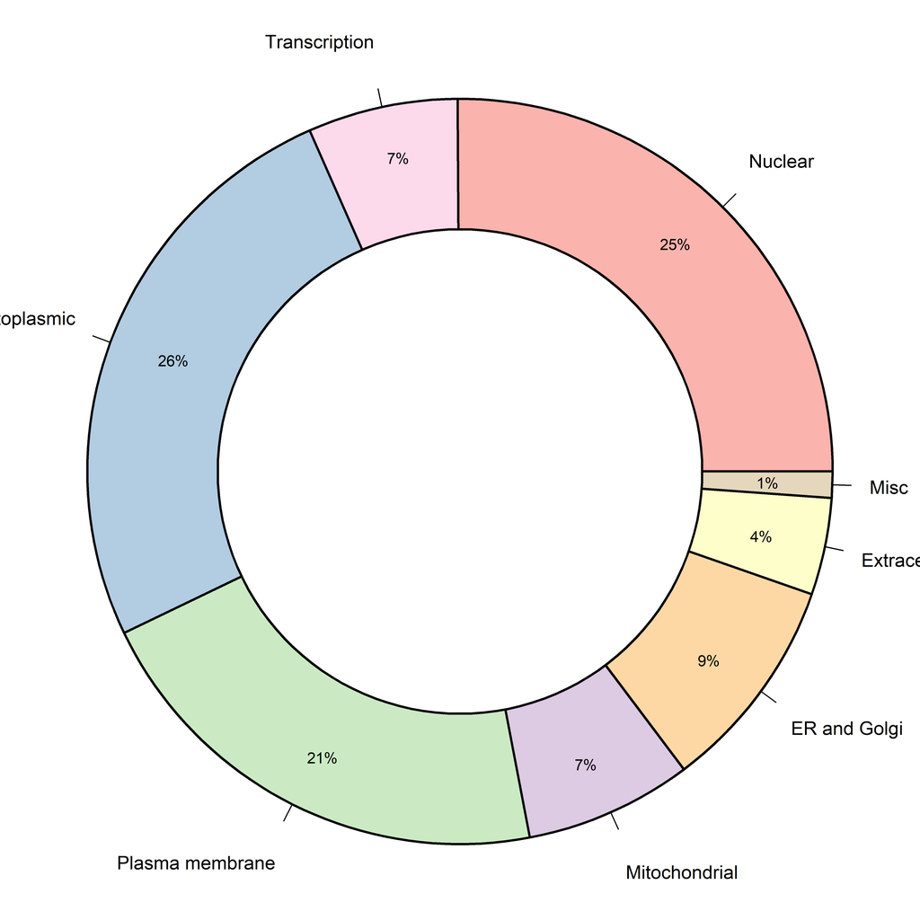

```r
gene_check <- RNAx5 %>%
  filter(Cells  == "1") %>%
  distinct(Gene)

gene_query <-queryMany(gene_check$Gene, scopes='symbol',
                       fields=c('go'), species='mouse',
                       returnall = FALSE )
gq2 <- gene_query %>%
  as.data.frame() %>%
  mutate(go.CC = unAsIs(go.CC)) %>%
  mutate(go.MF = unAsIs(go.MF))

gq3 <- gq2 %>%
  dplyr::select(-go.BP, -go.MF) %>%
  hoist(go.CC,
        term =  "term",
        evidence = "evidence",
        qualifier = "qualifier",
        id = "id") %>%
  unnest(term, evidence, qualifier, id) %>%
  dplyr::select(-go.CC)

gq4 <- gq2 %>%
  dplyr::select(-go.BP, -go.CC) %>%
  hoist(go.MF,
        term =  "term",
        evidence = "evidence",
        qualifier = "qualifier",
        id = "id") %>%
  unnest(term, evidence, qualifier, id) %>%
  dplyr::select(-go.MF)

 transcriptf <- gq4 %>%
  filter(grepl("transcription", term)) %>%
  distinct(query) %>%
  mutate(Component = "Transcription")


nuclearp <- gq3 %>%
  filter(term == "nucleus" | term == "nucleoplasm" | term == "nucleolus"| grepl("nuclear", term)) %>%
  filter(qualifier == "located_in") %>%
  distinct(query)%>%
  mutate(Component = "Nuclear")




cytoplasmic <- gq3 %>%
  filter(qualifier == "located_in") %>%
  filter(term == "cytoplasm" | term == "cytosol") %>%
  distinct(query) %>%
  mutate(Component = "Cytoplasmic")

mitochondrial <- gq3 %>%
  filter(qualifier == "located_in") %>%
  filter(term == "mitochondrion" | grepl("mitochondria", term)) %>%
  distinct(query) %>%
  mutate(Component = "Mitochondrial")

plasmamembrane <- gq3 %>%
  filter(qualifier == "located_in") %>%
  filter(term == "plasma membrane" | term == "membrane") %>%
  distinct(query) %>%
  mutate(Component = "Plasma membrane")


ER_golgi <- gq3 %>%
  filter(qualifier == "located_in") %>%
  filter(grepl("Golgi", term) | grepl("endoplasmic reticulum", term)) %>%
  distinct(query) %>%
  mutate(Component = "ER and Golgi")

extraCel <- gq3 %>%
  filter(qualifier == "located_in") %>%
  filter(grepl("extracellular", term)) %>%
  distinct(query) %>%
  mutate(Component = "Extracellular")

misc <- gq3 %>%
 filter(!query %in% transcriptf$query) %>%
  filter(!query %in% nuclearp$query) %>%
  filter(!query %in% cytoplasmic$query) %>%
  filter(!query %in% mitochondrial$query) %>%
  filter(!query %in% plasmamembrane$query) %>%
  filter(!query %in% ER_golgi$query) %>%
  filter(!query %in% extraCel$query) %>%
  filter(qualifier == "located_in") %>%
  distinct(query) %>%
  mutate(Component = "Misc")

protein_component <- do.call("rbind",list(transcriptf, nuclearp,
                                          cytoplasmic, mitochondrial,
                                          plasmamembrane, ER_golgi,
                                          extraCel, misc)) %>%
  mutate(Component = as.factor(Component)) %>%
  mutate(Component = fct_relevel(Component, "Nuclear",
                                  "Transcription",
                                  "Cytoplasmic",
                                  "Plasma membrane",
                                  "Mitochondrial",
                                  ))


cols <- c("#fbb4ae", "#fddaec", "#b3cde3", "#ccebc5",
          "#decbe4", "#fed9a6", "#ffffcc", "#e5d8bd")

PieChart(Component, data = protein_component,
         values = "%",
         fill = cols,
         lwd = 2,
         lty = 1,
         values_size = 0.8,
         values_color = "black",
         color = "black",
         main = NULL,
         width = 10,
         heigth = 10)+
  theme(text=element_text(family="Helvetica"))
```

# Supplementary Figures

## Supplementary Figure X

**Supplementary Figure: 11, 3, and 1 C10 cell protein LFQ intensity distributions before median normalization**

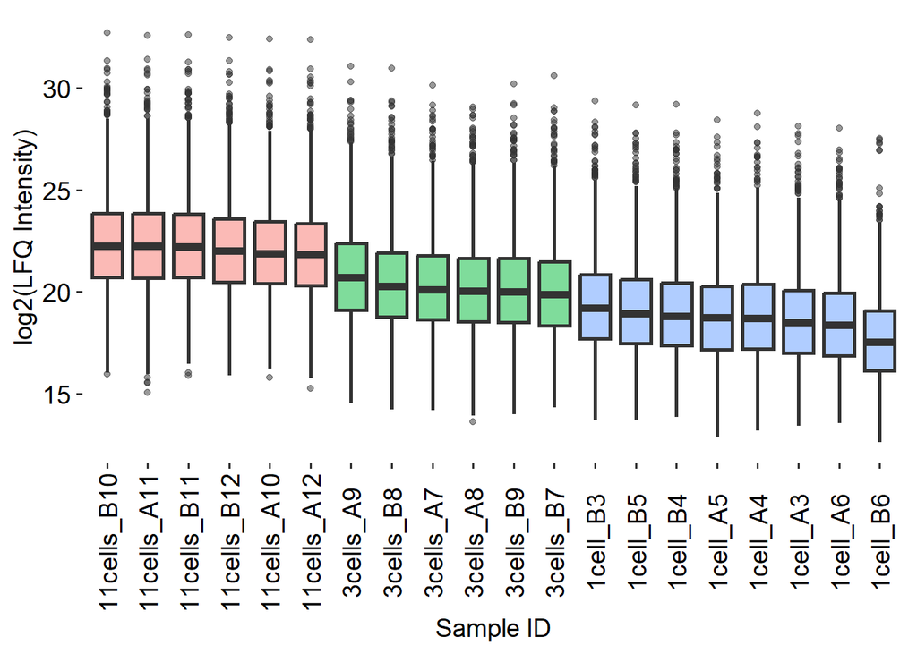

## Supplementary Figure X

**Supplementary Figure: 11, 3, and 1 C10 cell protein LFQ intensity distributions after median normalization**

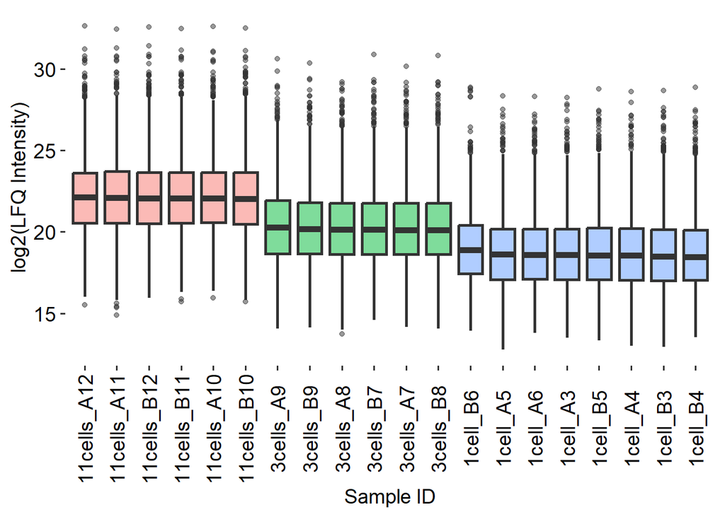

## Supplementary Figure X

**Supplementary Figure: Total number of proteins observed per dataset**

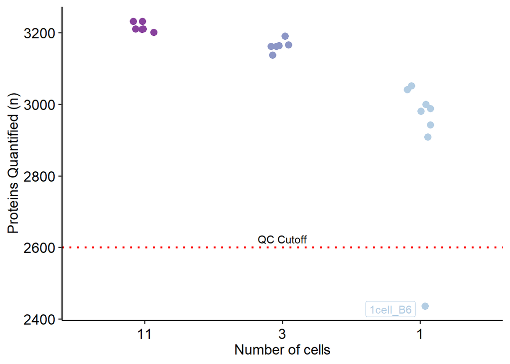

## Supplementary Figure X

**Supplementary Figure. Total genes detected with at least 5 raw counts in 11, 3, and 1 C10 cell after nanoSPLITS (transcriptomics)**

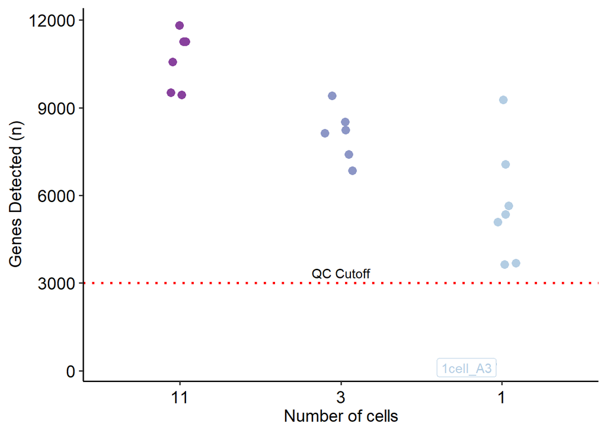

## Supplementary Figure X

**Supplementary Figure: Intensity distributions for 11, 3, and 1 C10 cell samples**

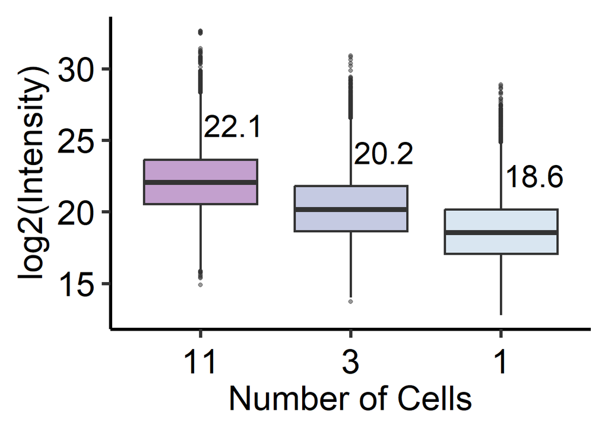

## Supplementary Figure X

**Supplementary Figure: Rank of proteins (riBAQ) based on median abundance across all samples**

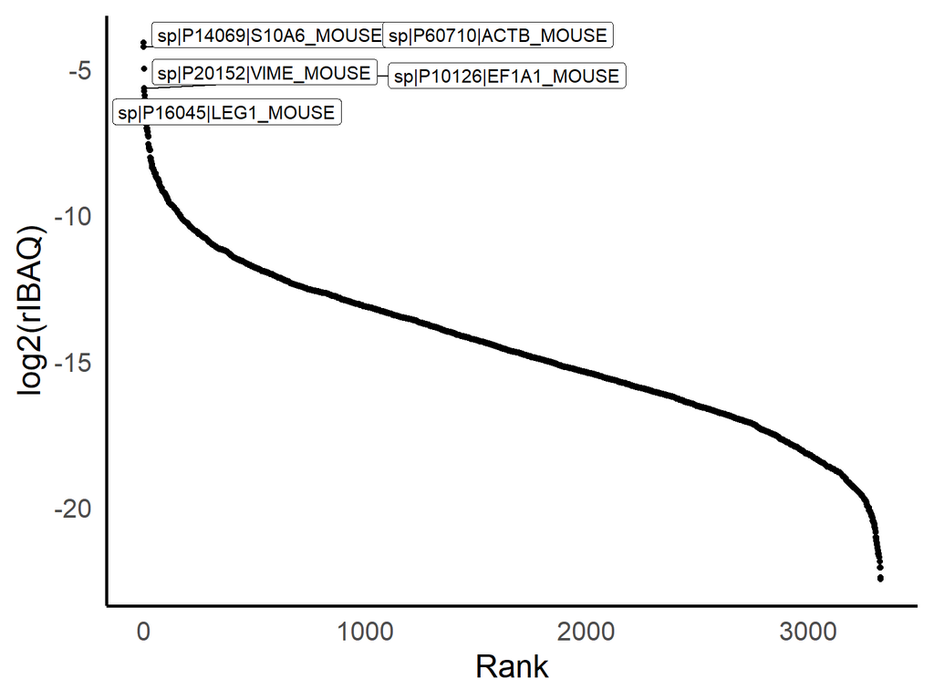

## Supplementary Figure X

**Supplementary Figure: Distributions of Pearson Correlation coefficients**

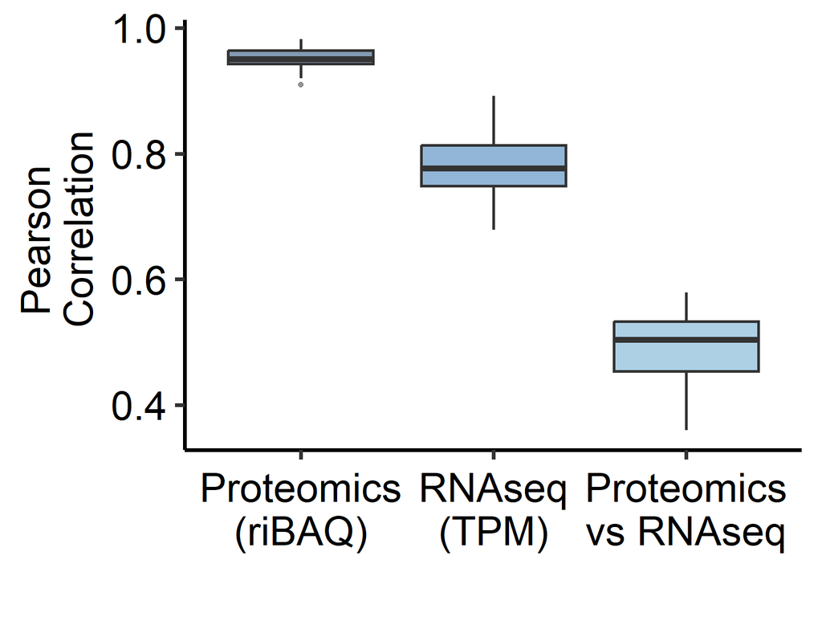

## Supplementary Figure X

**Supplementary Figure: Distribution of overlapping identifications (Gene/ Protein)**

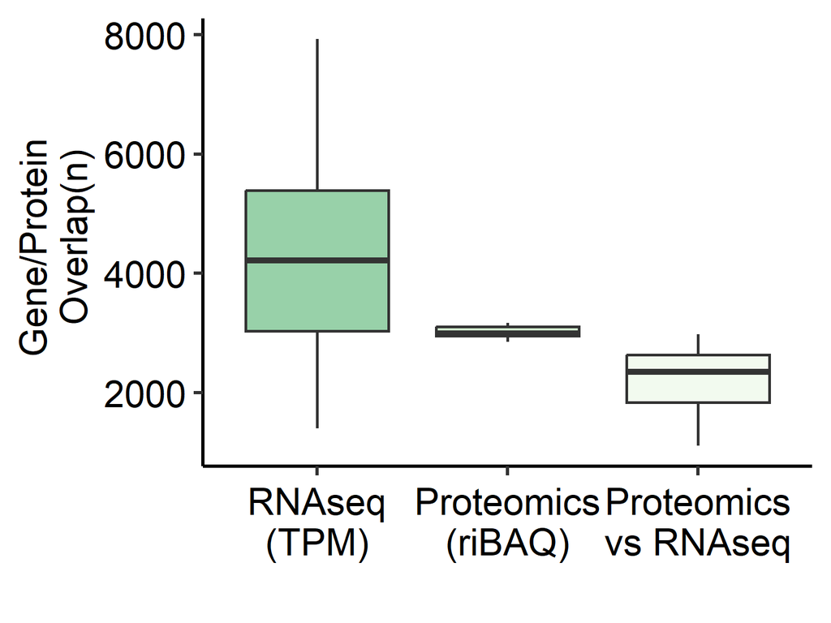